# Week 2 - Regression and model validation

This chapter describes the work done this week, the results and it’s interpretations.

## 1. Brief dataset description

The data we are working on was collected during course: Johdatus yhteiskuntatilastotieteeseen, syksy 2014 (Introduction to Social Statistics, fall 2014 - in Finnish), international survey of Approaches to Learning, made possible by Teachers’ Academy funding for KV in 2013-2015. Data are used for teaching purposes from 1/2017 on with a course Introduction to Open Data Science.

Data has totaly 166 observations and 7 variables: gender, age, attitude, deep, stra, surf and points.

```r
testData <- read.table("data/learning2014.txt")
dim(testData)
```

```
## [1] 166   7
```

```r
colnames(testData)
```

```
## [1] "gender"   "age"      "attitude" "deep"     "stra"     "surf"
## [7] "points"
```

## 2. Data overview

Summaries of the data variables:

- **gender** - Gender: M (Male), F (Female)
- **age** - Age (in years) derived from the date of birth
- **attitude** - Global attitude toward statistics
- **deep** - Average score on questions related to deep learning
- **stra** - Average score on questions related to strategic learning
- **surf** - Average score on questions related to surface learning
- **points** - Exam points

Graphical represtentaion of the data:

```r
library(GGally)
```

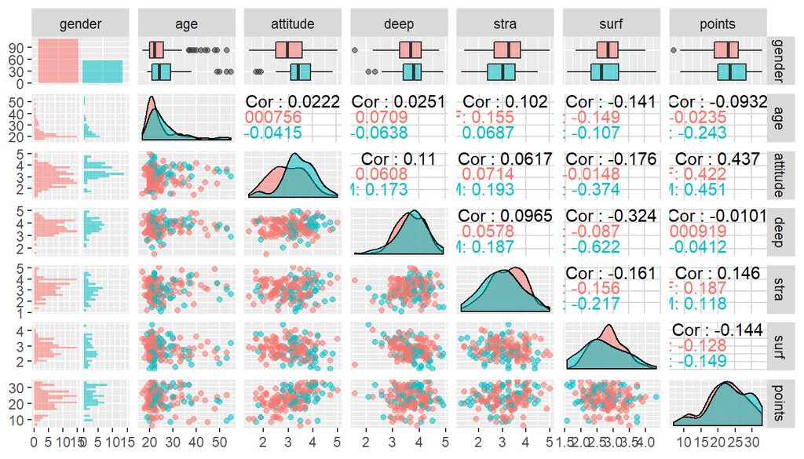

```r
library(ggplot2)
p <- ggpairs(testData, mapping = aes(col=gender, alpha = 0.3), lower = list(combo = wrap("facethist", bins = 20)))
p
```

## 3. Regression model

We are trying to fit a regression model where exam *points* is the target variable and explanatory variables are the three most significant variables in relation to the target: *attitude*, *stra* and *surf* .

```r
my_model <- lm(points ~ attitude + stra + surf, data = testData)
summary(my_model)
```

```
##
## Call:
## lm(formula = points ~ attitude + stra + surf, data = testData)
##
## Residuals:
##      Min       1Q   Median       3Q      Max
## -17.1550  -3.4346   0.5156   3.6401  10.8952
##
## Coefficients:
##             Estimate Std. Error t value Pr(>|t|)
## (Intercept)  11.0171     3.6837   2.991  0.00322 **
## attitude      3.3952     0.5741   5.913 1.93e-08 ***
## stra          0.8531     0.5416   1.575  0.11716
## surf         -0.5861     0.8014  -0.731  0.46563
## ---
## Signif. codes:  0 '***' 0.001 '**' 0.01 '*' 0.05 '.' 0.1 ' ' 1
##
## Residual standard error: 5.296 on 162 degrees of freedom
## Multiple R-squared:  0.2074, Adjusted R-squared:  0.1927
## F-statistic: 14.13 on 3 and 162 DF,  p-value: 3.156e-08
```

The summary of the model shows us residuals, as well as estimated parameters of the linear function, which gives us regression equation describing the relationship between exam *points* and *attitude*, *stra* and *surf* :

$points = \alpha + \beta_1 \cdot attitude + \beta_2 \cdot stra + \beta_3 \cdot surf$

and the estimates are:

$\alpha$ = 11.0171  
$\beta_1$ = 3.3952  
$\beta_2$ = 0.8531  
$\beta_3$ = -0.5861

Which gives us the regression equation:  
$points = 11.0171 + 3.3952 \cdot attitude + 0.8531 \cdot stra - 0.5861 \cdot surf$

## 4. Results interpretation

Intercept ($\alpha$) is a *points’* value when all of the 3 variables are equal to 0. That is the value where linear regression graph crosses the y-axis (the *points* axis). If *attitude* chages by one unit, exam *points* will change by 3.3952 units, given that the other variables do not change. Similarly, the same principle is valid for other variables and their parameters (if *stra* changes by one unit, *points* will change by 0.8531 units and if *surf* changes by one unit, *points* will change by -0.5861 units, given that other variables don’t change).

Multiple R-squared of the model is: 0.2074, that is 20.74%. This measure tells us how close the data are to the fitted regression line. The value being around 20% indicates that the model explains some of the variability of the response data around its mean.

## 5. Diagnostic plots

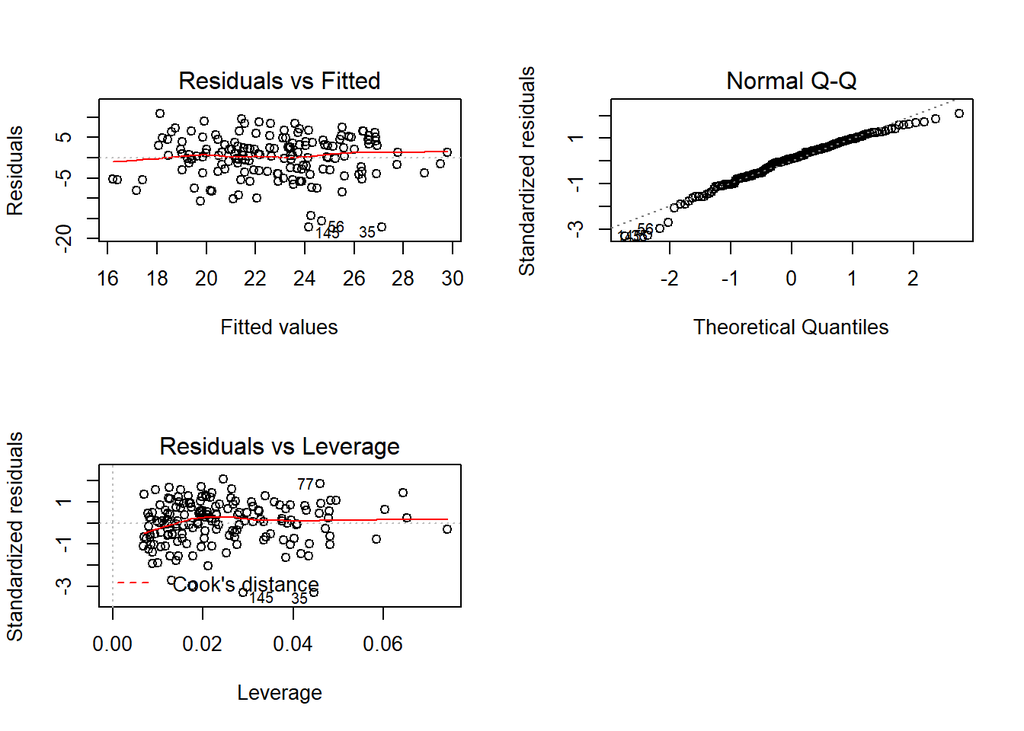

```r
par(mfrow = c(2,2))
plot(my_model, which=c(1,2,5))
```

**Residuals vs Fitted plot** shows that residuals don’t have a non-linear pattern which means that linear model is good for analysis of our data.

**Normal QQ-plot** shows us that the residuals were normally distributed, which is also a sign of a good model.

**Residuals vs Leverage plot** helps to find influential outliners. In our plot I don’t see any influential outliners. We can’t even see Cook’s distance lines (a red dashed line) because all cases are well inside of the Cook’s distance lines.

These three plots show us that there isn’t anything problematic in our model and that it is a good representation of our data.